# Report EN1 ko transcriptome analysis, differential expression analysis unstimulated vs stimulated

Sebastian Schmidt

12 März, 2024

# 1 Loading of data and normalization

## 1.1 Count matrix

First, we load the count matrix.

This is how the full count matrix looks like (first 100 rows, to speed things up):

|  | 5-6_unstimulated_1 | 5-6_unstimulated_2 | 5-6_unstimulated_3 | 5-12_unstimulated_1 | 5-12_unstimulated_2 | 5-12_unstimulated_3 | 25-19_unstimulated_1 | 25-19_unstimulated_2 | 25-19_unstimulated_3 | 4-3_unstimulated_1 | 4-3_unstimulated_2 | 4-3_unstimulated_3 | 4-4_unstimulated_1 | 4-4_unstimulated_2 | 4-4_unstimulated_3 | 4-5_unstimulated_1 | 4-5_unstimulated_2 | 4-5_unstimulated_3 | 15-1_unstimulated_1 | 15-1_unstimulated_2 | 15-1_unstimulated_3 | 5-6_stimulated_1 | 5-6_stimulated_2 | 5-6_stimulated_3 | 5-12_stimulated_1 | 5-12_stimulated_2 | 5-12_stimulated_3 | 25-19_stimulated_1 | 25-19_stimulated_2 | … |
| --- | --- | --- | --- | --- | --- | --- | --- | --- | --- | --- | --- | --- | --- | --- | --- | --- | --- | --- | --- | --- | --- | --- | --- | --- | --- | --- | --- | --- | --- | --- |
| ENSG00000000003.15 | 4852 | 3894 | 3755 | 4257 | 4252 | 4465 | 4070 | 3755 | 3835 | 4905 | 4965 | 5448 | 6216 | 7428 | 6324 | 6849 | 4844 | 5185 | 5529 | 6698 | 8205 | 3566 | 3959 | 3911 | 3949 | 3145 | 3582 | 2675 | 2913 | … |
| ENSG00000000005.6 | 6 | 2 | 1 | 5 | 0 | 4 | 3 | 2 | 1 | 1 | 1 | 0 | 5 | 6 | 8 | 6 | 6 | 7 | 8 | 3 | 2 | 2 | 3 | 3 | 0 | 2 | 1 | 0 | 1 | … |
| ENSG00000000419.12 | 1001 | 929 | 929 | 985 | 933 | 878 | 1093 | 876 | 874 | 1017 | 1073 | 1111 | 1375 | 1312 | 1080 | 1346 | 904 | 983 | 1025 | 1191 | 1296 | 1466 | 1661 | 1510 | 1452 | 1087 | 1134 | 1101 | 1256 | … |
| ENSG00000000457.14 | 373 | 292 | 307 | 308 | 290 | 307 | 392 | 372 | 354 | 389 | 382 | 391 | 381 | 471 | 376 | 501 | 361 | 317 | 401 | 447 | 444 | 370 | 453 | 364 | 364 | 294 | 319 | 317 | 355 | … |
| ENSG00000000460.17 | 574 | 483 | 431 | 480 | 493 | 481 | 432 | 452 | 392 | 637 | 633 | 666 | 691 | 778 | 691 | 758 | 518 | 532 | 665 | 775 | 940 | 651 | 733 | 683 | 700 | 637 | 616 | 520 | 576 | … |
| ENSG00000000938.13 | 0 | 1 | 1 | 0 | 1 | 0 | 1 | 0 | 2 | 2 | 0 | 0 | 3 | 2 | 0 | 0 | 2 | 0 | 1 | 2 | 0 | 3 | 1 | 1 | 2 | 3 | 1 | 0 | 2 | … |
| ENSG00000000971.15 | 0 | 0 | 0 | 2 | 0 | 0 | 0 | 1 | 0 | 0 | 4 | 5 | 7 | 8 | 4 | 14 | 3 | 13 | 13 | 18 | 16 | 0 | 1 | 0 | 0 | 0 | 0 | 0 | 2 | … |
| ENSG00000001036.14 | 1874 | 1565 | 1571 | 1552 | 1516 | 1502 | 1897 | 1797 | 1758 | 1510 | 1636 | 1892 | 1710 | 1824 | 1494 | 2070 | 1442 | 1501 | 1712 | 2005 | 1996 | 1871 | 2237 | 2032 | 2045 | 1645 | 1703 | 1816 | 2110 | … |
| ENSG00000001084.13 | 647 | 586 | 630 | 759 | 657 | 568 | 940 | 757 | 602 | 786 | 732 | 819 | 834 | 890 | 659 | 1117 | 706 | 731 | 896 | 953 | 919 | 732 | 897 | 701 | 814 | 704 | 654 | 648 | 713 | … |
| ENSG00000001167.14 | 1805 | 1618 | 1579 | 1879 | 1644 | 1527 | 2037 | 1926 | 1593 | 1620 | 1703 | 1921 | 1790 | 1881 | 1552 | 2700 | 1717 | 1971 | 1980 | 2352 | 2284 | 1469 | 1802 | 1536 | 1660 | 1312 | 1375 | 1379 | 1620 | … |

[output cut: 90 more lines]

This is how the full sample matrix looks like

|  | 5-6_unstimulated_1 | 5-6_unstimulated_2 | 5-6_unstimulated_3 | 5-12_unstimulated_1 | 5-12_unstimulated_2 | 5-12_unstimulated_3 | 25-19_unstimulated_1 | 25-19_unstimulated_2 | 25-19_unstimulated_3 | 4-3_unstimulated_1 | 4-3_unstimulated_2 | 4-3_unstimulated_3 | 4-4_unstimulated_1 | 4-4_unstimulated_2 | 4-4_unstimulated_3 | 4-5_unstimulated_1 | 4-5_unstimulated_2 | 4-5_unstimulated_3 | 15-1_unstimulated_1 | 15-1_unstimulated_2 | 15-1_unstimulated_3 | 5-6_stimulated_1 | 5-6_stimulated_2 | 5-6_stimulated_3 | 5-12_stimulated_1 | 5-12_stimulated_2 | 5-12_stimulated_3 | 25-19_stimulated_1 | 25-19_stimulated_2 | … |
| --- | --- | --- | --- | --- | --- | --- | --- | --- | --- | --- | --- | --- | --- | --- | --- | --- | --- | --- | --- | --- | --- | --- | --- | --- | --- | --- | --- | --- | --- | --- |
| stimulation | unstim | unstim | unstim | unstim | unstim | unstim | unstim | unstim | unstim | unstim | unstim | unstim | unstim | unstim | unstim | unstim | unstim | unstim | unstim | unstim | unstim | stim | stim | stim | stim | stim | stim | stim | stim | … |
| condition | ko_hom | ko_hom | ko_hom | ko_hom | ko_hom | ko_hom | ko_hom | ko_hom | ko_hom | ctrl | ctrl | ctrl | ctrl | ctrl | ctrl | ctrl | ctrl | ctrl | ctrl | ctrl | ctrl | ko_hom | ko_hom | ko_hom | ko_hom | ko_hom | ko_hom | ko_hom | ko_hom | … |
| sample | 5-6 | 5-6 | 5-6 | 5-12 | 5-12 | 5-12 | 25-19 | 25-19 | 25-19 | 4-3 | 4-3 | 4-3 | 4-4 | 4-4 | 4-4 | 4-5 | 4-5 | 4-5 | 15-1 | 15-1 | 15-1 | 5-6 | 5-6 | 5-6 | 5-12 | 5-12 | 5-12 | 25-19 | 25-19 | … |
| repeat | 1 | 2 | 3 | 1 | 2 | 3 | 1 | 2 | 3 | 1 | 2 | 3 | 1 | 2 | 3 | 1 | 2 | 3 | 1 | 2 | 3 | 1 | 2 | 3 | 1 | 2 | 3 | 1 | 2 | … |
| sample_wStim | 5-6_unstim | 5-6_unstim | 5-6_unstim | 5-12_unstim | 5-12_unstim | 5-12_unstim | 25-19_unstim | 25-19_unstim | 25-19_unstim | 4-3_unstim | 4-3_unstim | 4-3_unstim | 4-4_unstim | 4-4_unstim | 4-4_unstim | 4-5_unstim | 4-5_unstim | 4-5_unstim | 15-1_unstim | 15-1_unstim | 15-1_unstim | 5-6_stim | 5-6_stim | 5-6_stim | 5-12_stim | 5-12_stim | 5-12_stim | 25-19_stim | 25-19_stim | … |
| sample.n | 1 | 1 | 1 | 2 | 2 | 2 | 3 | 3 | 3 | 1 | 1 | 1 | 2 | 2 | 2 | 3 | 3 | 3 | 4 | 4 | 4 | 1 | 1 | 1 | 2 | 2 | 2 | 3 | 3 | … |

This is how the count matrix for the Ctrl samples - unstimulated and Wnt stimulated - looks like (first 100 rows, to speed things up):

|  | 4-3_unstimulated_1 | 4-3_unstimulated_2 | 4-3_unstimulated_3 | 4-4_unstimulated_1 | 4-4_unstimulated_2 | 4-4_unstimulated_3 | 4-5_unstimulated_1 | 4-5_unstimulated_2 | 4-5_unstimulated_3 | 15-1_unstimulated_1 | 15-1_unstimulated_2 | 15-1_unstimulated_3 | 4-3_stimulated_1 | 4-3_stimulated_2 | 4-3_stimulated_3 | 4-4_stimulated_1 | 4-4_stimulated_2 | 4-4_stimulated_3 | 4-5_stimulated_1 | 4-5_stimulated_2 | 4-5_stimulated_3 | 15-1_stimulated_1 | 15-1_stimulated_2 | 15-1_stimulated_3 |
| --- | --- | --- | --- | --- | --- | --- | --- | --- | --- | --- | --- | --- | --- | --- | --- | --- | --- | --- | --- | --- | --- | --- | --- | --- |
| ENSG00000000003.15 | 4905 | 4965 | 5448 | 6216 | 7428 | 6324 | 6849 | 4844 | 5185 | 5529 | 6698 | 8205 | 4230 | 4561 | 3935 | 4955 | 4307 | 4238 | 4187 | 3495 | 3848 | 4144 | 5612 | 5510 |
| ENSG00000000005.6 | 1 | 1 | 0 | 5 | 6 | 8 | 6 | 6 | 7 | 8 | 3 | 2 | 0 | 2 | 0 | 1 | 0 | 2 | 2 | 0 | 1 | 2 | 5 | 0 |
| ENSG00000000419.12 | 1017 | 1073 | 1111 | 1375 | 1312 | 1080 | 1346 | 904 | 983 | 1025 | 1191 | 1296 | 1458 | 1462 | 1253 | 1465 | 1090 | 1014 | 1142 | 1030 | 1145 | 1190 | 1495 | 1404 |
| ENSG00000000457.14 | 389 | 382 | 391 | 381 | 471 | 376 | 501 | 361 | 317 | 401 | 447 | 444 | 376 | 383 | 357 | 403 | 270 | 331 | 301 | 255 | 308 | 308 | 422 | 361 |
| ENSG00000000460.17 | 637 | 633 | 666 | 691 | 778 | 691 | 758 | 518 | 532 | 665 | 775 | 940 | 788 | 745 | 721 | 853 | 674 | 661 | 657 | 581 | 657 | 713 | 870 | 834 |
| ENSG00000000938.13 | 2 | 0 | 0 | 3 | 2 | 0 | 0 | 2 | 0 | 1 | 2 | 0 | 0 | 0 | 2 | 2 | 2 | 2 | 0 | 0 | 2 | 0 | 1 | 1 |
| ENSG00000000971.15 | 0 | 4 | 5 | 7 | 8 | 4 | 14 | 3 | 13 | 13 | 18 | 16 | 2 | 0 | 1 | 1 | 4 | 1 | 3 | 2 | 5 | 5 | 9 | 5 |
| ENSG00000001036.14 | 1510 | 1636 | 1892 | 1710 | 1824 | 1494 | 2070 | 1442 | 1501 | 1712 | 2005 | 1996 | 2037 | 2045 | 2104 | 2210 | 1831 | 1803 | 1691 | 1604 | 1949 | 1963 | 2353 | 2067 |
| ENSG00000001084.13 | 786 | 732 | 819 | 834 | 890 | 659 | 1117 | 706 | 731 | 896 | 953 | 919 | 983 | 791 | 917 | 1040 | 761 | 831 | 667 | 630 | 804 | 859 | 1007 | 838 |
| ENSG00000001167.14 | 1620 | 1703 | 1921 | 1790 | 1881 | 1552 | 2700 | 1717 | 1971 | 1980 | 2352 | 2284 | 1742 | 1551 | 1728 | 1739 | 1393 | 1518 | 1424 | 1399 | 1620 | 1733 | 2012 | 1666 |

[output cut: 90 more lines]

This is how the sample matrix for the Ctrl samples - unstimulated and Wnt stimulated - looks like

|  | 4-3_unstimulated_1 | 4-3_unstimulated_2 | 4-3_unstimulated_3 | 4-4_unstimulated_1 | 4-4_unstimulated_2 | 4-4_unstimulated_3 | 4-5_unstimulated_1 | 4-5_unstimulated_2 | 4-5_unstimulated_3 | 15-1_unstimulated_1 | 15-1_unstimulated_2 | 15-1_unstimulated_3 | 4-3_stimulated_1 | 4-3_stimulated_2 | 4-3_stimulated_3 | 4-4_stimulated_1 | 4-4_stimulated_2 | 4-4_stimulated_3 | 4-5_stimulated_1 | 4-5_stimulated_2 | 4-5_stimulated_3 | 15-1_stimulated_1 | 15-1_stimulated_2 | 15-1_stimulated_3 |
| --- | --- | --- | --- | --- | --- | --- | --- | --- | --- | --- | --- | --- | --- | --- | --- | --- | --- | --- | --- | --- | --- | --- | --- | --- |
| stimulation | unstim | unstim | unstim | unstim | unstim | unstim | unstim | unstim | unstim | unstim | unstim | unstim | stim | stim | stim | stim | stim | stim | stim | stim | stim | stim | stim | stim |
| condition | ctrl | ctrl | ctrl | ctrl | ctrl | ctrl | ctrl | ctrl | ctrl | ctrl | ctrl | ctrl | ctrl | ctrl | ctrl | ctrl | ctrl | ctrl | ctrl | ctrl | ctrl | ctrl | ctrl | ctrl |
| sample | 4-3 | 4-3 | 4-3 | 4-4 | 4-4 | 4-4 | 4-5 | 4-5 | 4-5 | 15-1 | 15-1 | 15-1 | 4-3 | 4-3 | 4-3 | 4-4 | 4-4 | 4-4 | 4-5 | 4-5 | 4-5 | 15-1 | 15-1 | 15-1 |
| repeat | 1 | 2 | 3 | 1 | 2 | 3 | 1 | 2 | 3 | 1 | 2 | 3 | 1 | 2 | 3 | 1 | 2 | 3 | 1 | 2 | 3 | 1 | 2 | 3 |
| sample_wStim | 4-3_unstim | 4-3_unstim | 4-3_unstim | 4-4_unstim | 4-4_unstim | 4-4_unstim | 4-5_unstim | 4-5_unstim | 4-5_unstim | 15-1_unstim | 15-1_unstim | 15-1_unstim | 4-3_stim | 4-3_stim | 4-3_stim | 4-4_stim | 4-4_stim | 4-4_stim | 4-5_stim | 4-5_stim | 4-5_stim | 15-1_stim | 15-1_stim | 15-1_stim |
| sample.n | 1 | 1 | 1 | 2 | 2 | 2 | 3 | 3 | 3 | 4 | 4 | 4 | 1 | 1 | 1 | 2 | 2 | 2 | 3 | 3 | 3 | 4 | 4 | 4 |

|  | 4-3_unstimulated_1 | 4-3_unstimulated_2 | 4-3_unstimulated_3 | 4-4_unstimulated_1 | 4-4_unstimulated_2 | 4-4_unstimulated_3 | 4-5_unstimulated_1 | 4-5_unstimulated_2 | 4-5_unstimulated_3 | 15-1_unstimulated_1 | 15-1_unstimulated_2 | 15-1_unstimulated_3 | 4-3_stimulated_1 | 4-3_stimulated_2 | 4-3_stimulated_3 | 4-4_stimulated_1 | 4-4_stimulated_2 | 4-4_stimulated_3 | 4-5_stimulated_1 | 4-5_stimulated_2 | 4-5_stimulated_3 | 15-1_stimulated_1 | 15-1_stimulated_2 | 15-1_stimulated_3 |
| --- | --- | --- | --- | --- | --- | --- | --- | --- | --- | --- | --- | --- | --- | --- | --- | --- | --- | --- | --- | --- | --- | --- | --- | --- |
| ENSG00000000003.15 | 4905 | 4965 | 5448 | 6216 | 7428 | 6324 | 6849 | 4844 | 5185 | 5529 | 6698 | 8205 | 4230 | 4561 | 3935 | 4955 | 4307 | 4238 | 4187 | 3495 | 3848 | 4144 | 5612 | 5510 |
| ENSG00000000005.6 | 1 | 1 | 0 | 5 | 6 | 8 | 6 | 6 | 7 | 8 | 3 | 2 | 0 | 2 | 0 | 1 | 0 | 2 | 2 | 0 | 1 | 2 | 5 | 0 |
| ENSG00000000419.12 | 1017 | 1073 | 1111 | 1375 | 1312 | 1080 | 1346 | 904 | 983 | 1025 | 1191 | 1296 | 1458 | 1462 | 1253 | 1465 | 1090 | 1014 | 1142 | 1030 | 1145 | 1190 | 1495 | 1404 |
| ENSG00000000457.14 | 389 | 382 | 391 | 381 | 471 | 376 | 501 | 361 | 317 | 401 | 447 | 444 | 376 | 383 | 357 | 403 | 270 | 331 | 301 | 255 | 308 | 308 | 422 | 361 |
| ENSG00000000460.17 | 637 | 633 | 666 | 691 | 778 | 691 | 758 | 518 | 532 | 665 | 775 | 940 | 788 | 745 | 721 | 853 | 674 | 661 | 657 | 581 | 657 | 713 | 870 | 834 |
| ENSG00000000938.13 | 2 | 0 | 0 | 3 | 2 | 0 | 0 | 2 | 0 | 1 | 2 | 0 | 0 | 0 | 2 | 2 | 2 | 2 | 0 | 0 | 2 | 0 | 1 | 1 |
| ENSG00000000971.15 | 0 | 4 | 5 | 7 | 8 | 4 | 14 | 3 | 13 | 13 | 18 | 16 | 2 | 0 | 1 | 1 | 4 | 1 | 3 | 2 | 5 | 5 | 9 | 5 |
| ENSG00000001036.14 | 1510 | 1636 | 1892 | 1710 | 1824 | 1494 | 2070 | 1442 | 1501 | 1712 | 2005 | 1996 | 2037 | 2045 | 2104 | 2210 | 1831 | 1803 | 1691 | 1604 | 1949 | 1963 | 2353 | 2067 |
| ENSG00000001084.13 | 786 | 732 | 819 | 834 | 890 | 659 | 1117 | 706 | 731 | 896 | 953 | 919 | 983 | 791 | 917 | 1040 | 761 | 831 | 667 | 630 | 804 | 859 | 1007 | 838 |
| ENSG00000001167.14 | 1620 | 1703 | 1921 | 1790 | 1881 | 1552 | 2700 | 1717 | 1971 | 1980 | 2352 | 2284 | 1742 | 1551 | 1728 | 1739 | 1393 | 1518 | 1424 | 1399 | 1620 | 1733 | 2012 | 1666 |

[output cut: 90 more lines]

|  | 4-3_unstimulated_1 | 4-3_unstimulated_2 | 4-3_unstimulated_3 | 4-4_unstimulated_1 | 4-4_unstimulated_2 | 4-4_unstimulated_3 | 4-5_unstimulated_1 | 4-5_unstimulated_2 | 4-5_unstimulated_3 | 15-1_unstimulated_1 | 15-1_unstimulated_2 | 15-1_unstimulated_3 | 4-3_stimulated_1 | 4-3_stimulated_2 | 4-3_stimulated_3 | 4-4_stimulated_1 | 4-4_stimulated_2 | 4-4_stimulated_3 | 4-5_stimulated_1 | 4-5_stimulated_2 | 4-5_stimulated_3 | 15-1_stimulated_1 | 15-1_stimulated_2 | 15-1_stimulated_3 |
| --- | --- | --- | --- | --- | --- | --- | --- | --- | --- | --- | --- | --- | --- | --- | --- | --- | --- | --- | --- | --- | --- | --- | --- | --- |
| stimulation | unstim | unstim | unstim | unstim | unstim | unstim | unstim | unstim | unstim | unstim | unstim | unstim | stim | stim | stim | stim | stim | stim | stim | stim | stim | stim | stim | stim |
| condition | ctrl | ctrl | ctrl | ctrl | ctrl | ctrl | ctrl | ctrl | ctrl | ctrl | ctrl | ctrl | ctrl | ctrl | ctrl | ctrl | ctrl | ctrl | ctrl | ctrl | ctrl | ctrl | ctrl | ctrl |
| sample | 4-3 | 4-3 | 4-3 | 4-4 | 4-4 | 4-4 | 4-5 | 4-5 | 4-5 | 15-1 | 15-1 | 15-1 | 4-3 | 4-3 | 4-3 | 4-4 | 4-4 | 4-4 | 4-5 | 4-5 | 4-5 | 15-1 | 15-1 | 15-1 |
| repeat | 1 | 2 | 3 | 1 | 2 | 3 | 1 | 2 | 3 | 1 | 2 | 3 | 1 | 2 | 3 | 1 | 2 | 3 | 1 | 2 | 3 | 1 | 2 | 3 |
| sample_wStim | 4-3_unstim | 4-3_unstim | 4-3_unstim | 4-4_unstim | 4-4_unstim | 4-4_unstim | 4-5_unstim | 4-5_unstim | 4-5_unstim | 15-1_unstim | 15-1_unstim | 15-1_unstim | 4-3_stim | 4-3_stim | 4-3_stim | 4-4_stim | 4-4_stim | 4-4_stim | 4-5_stim | 4-5_stim | 4-5_stim | 15-1_stim | 15-1_stim | 15-1_stim |
| sample.n | 1 | 1 | 1 | 2 | 2 | 2 | 3 | 3 | 3 | 4 | 4 | 4 | 1 | 1 | 1 | 2 | 2 | 2 | 3 | 3 | 3 | 4 | 4 | 4 |

# 2 Differential expression analysis for ctrl lines - unstimulated vs. Wnt stimulated

We performed a differential gene expression analysis using DESeq2.

## 2.1 Differential expression analysis with DESeq2

This is how our experimental design table looks like for the Ctrl samples - unstimulated and Wnt stimulated.

| sample | stimulation | clone | replicate | clone.n |
| --- | --- | --- | --- | --- |
| 4-3_unstimulated_1 | unstim | 4-3 | 1 | 1 |
| 4-3_unstimulated_2 | unstim | 4-3 | 2 | 1 |
| 4-3_unstimulated_3 | unstim | 4-3 | 3 | 1 |
| 4-4_unstimulated_1 | unstim | 4-4 | 1 | 2 |
| 4-4_unstimulated_2 | unstim | 4-4 | 2 | 2 |
| 4-4_unstimulated_3 | unstim | 4-4 | 3 | 2 |
| 4-5_unstimulated_1 | unstim | 4-5 | 1 | 3 |
| 4-5_unstimulated_2 | unstim | 4-5 | 2 | 3 |
| 4-5_unstimulated_3 | unstim | 4-5 | 3 | 3 |
| 15-1_unstimulated_1 | unstim | 15-1 | 1 | 4 |
| 15-1_unstimulated_2 | unstim | 15-1 | 2 | 4 |
| 15-1_unstimulated_3 | unstim | 15-1 | 3 | 4 |
| 4-3_stimulated_1 | stim | 4-3 | 1 | 1 |
| 4-3_stimulated_2 | stim | 4-3 | 2 | 1 |
| 4-3_stimulated_3 | stim | 4-3 | 3 | 1 |
| 4-4_stimulated_1 | stim | 4-4 | 1 | 2 |
| 4-4_stimulated_2 | stim | 4-4 | 2 | 2 |
| 4-4_stimulated_3 | stim | 4-4 | 3 | 2 |
| 4-5_stimulated_1 | stim | 4-5 | 1 | 3 |
| 4-5_stimulated_2 | stim | 4-5 | 2 | 3 |
| 4-5_stimulated_3 | stim | 4-5 | 3 | 3 |
| 15-1_stimulated_1 | stim | 15-1 | 1 | 4 |
| 15-1_stimulated_2 | stim | 15-1 | 2 | 4 |
| 15-1_stimulated_3 | stim | 15-1 | 3 | 4 |

We will perform a DEG analysis using a nested approach (design = ~clone.n + clone.n:replicate + stimulation) to compensate for dependencies / replicates within the groups.

And these are the results of our differential gene expression analysis for the Ctrl samples - unstimulated and Wnt stimulated (top 100 DEGs). Only genes with a significant adjusted p-value and no fold change threshold are shown.

|  | baseMean | log2FoldChange | lfcSE | stat | pvalue | padj | symbol | description |
| --- | --- | --- | --- | --- | --- | --- | --- | --- |
| ENSG00000118523.6 | 3134.34506858103 | -4.971082422784391 | 0.1848469036236804 | -26.89297102268341 | 2.653953281289577e-159 | 1.044500741397788e-156 | CCN2 | cellular communication network factor 2 [Source:HGNC Symbol;Acc:HGNC:2500] |
| ENSG00000197406.7 | 724.7984924598502 | -4.080934552347275 | 0.2079365273202796 | -19.62586662833658 | 9.2978034142672e-86 | 8.017527225032992e-84 | DIO3 | iodothyronine deiodinase 3 [Source:HGNC Symbol;Acc:HGNC:2885] |
| ENSG00000102195.10 | 456.9853658597293 | -3.566610764786597 | 0.1240130593412959 | -28.75996111805403 | 6.799331346607034e-182 | 3.26134177622098e-179 | GPR50 | G protein-coupled receptor 50 [Source:HGNC Symbol;Acc:HGNC:4506] |
| ENSG00000144810.16 | 575.2376673235411 | -3.458205548114975 | 0.1818113175145122 | -19.02084862147781 | 1.146133499219728e-80 | 8.539807320157088e-79 | COL8A1 | collagen type VIII alpha 1 chain [Source:HGNC Symbol;Acc:HGNC:2215] |
| ENSG00000186960.12 | 683.3917226572845 | -3.294033910287403 | 0.08054976201719792 | -40.89439655432011 | 0 | 0 | LINC01551 | long intergenic non-protein coding RNA 1551 [Source:HGNC Symbol;Acc:HGNC:19828] |
| ENSG00000163251.4 | 1174.147217039466 | -3.144503673094183 | 0.1875360832856086 | -16.76745945635034 | 4.221773760386365e-63 | 1.934328520840905e-61 | FZD5 | frizzled class receptor 5 [Source:HGNC Symbol;Acc:HGNC:4043] |
| ENSG00000175899.14 | 1985.186511272225 | -3.10917289985932 | 0.1785960436931601 | -17.40896850548989 | 7.05435032726908e-68 | 3.746616718797686e-66 | A2M | alpha-2-macroglobulin [Source:HGNC Symbol;Acc:HGNC:7] |
| ENSG00000180730.4 | 581.6254643153535 | -3.082399777938612 | 0.384597932667018 | -8.014603085782394 | 1.104932537390406e-15 | 6.281336857927904e-15 | SHISA2 | shisa family member 2 [Source:HGNC Symbol;Acc:HGNC:20366] |
| ENSG00000154736.6 | 187.5866697678728 | -3.027478349093564 | 0.1672356119239722 | -18.10307215229912 | 3.013793741835213e-73 | 1.888111026262395e-71 | ADAMTS5 | ADAM metallopeptidase with thrombospondin type 1 motif 5 [Source:HGNC Symbol;Acc:HGNC:221] |
| ENSG00000149591.17 | 596.885452513468 | -3.008591806821282 | 0.1239929829639816 | -24.26421023918135 | 4.681542643398543e-130 | 1.105492277438834e-127 | TAGLN | transgelin [Source:HGNC Symbol;Acc:HGNC:11553] |

[output cut: 90 more lines]

## 2.2 Visualization of DEGs

Next, we employ a number of visualization methods

### 2.2.1 MA-plot

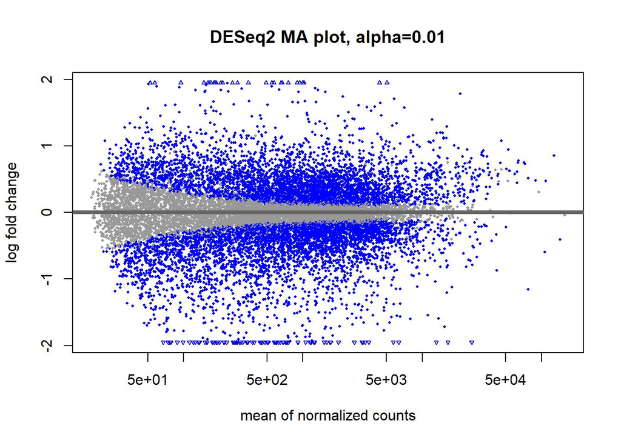

### 2.2.2 Vulcano-plot

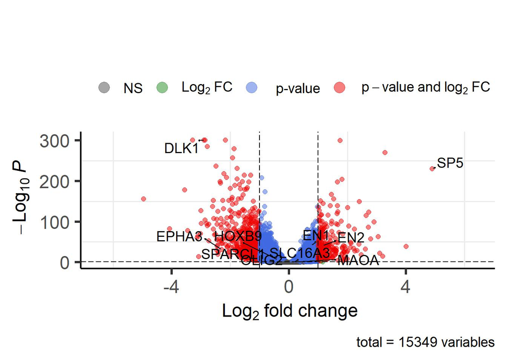

### 2.2.3 Heatmap

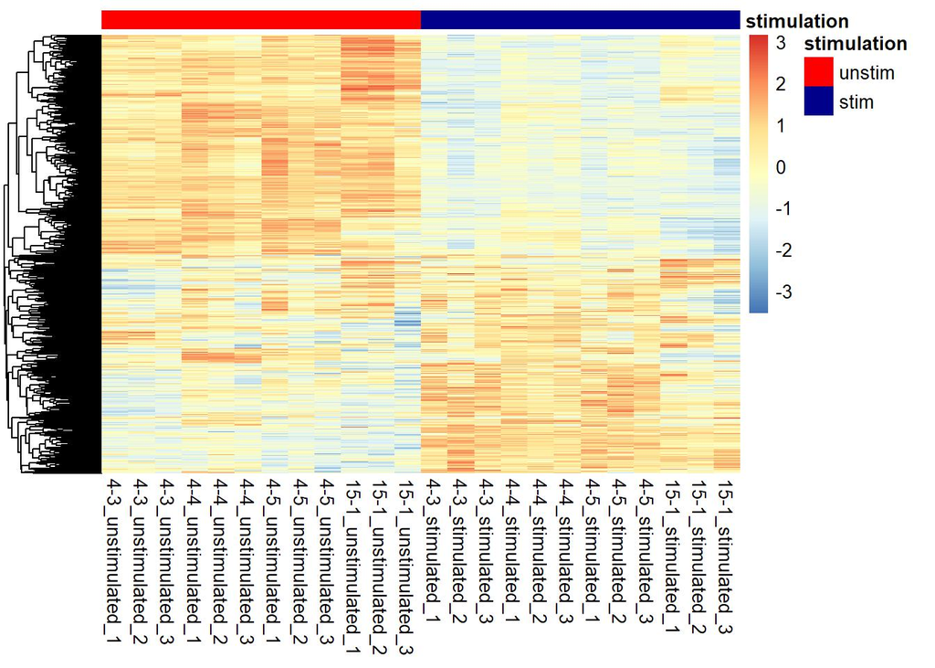

# 3 Differential expression analysis for EN1 ko lines - unstimulated vs. Wnt stimulated

We performed a differential gene expression analysis using DESeq2.

## 3.1 Differential expression analysis with DESeq2

This is how our experimental design table looks like for the EN1 ko samples - unstimulated and Wnt stimulated.

| sample | stimulation | clone | replicate | clone.n |
| --- | --- | --- | --- | --- |
| 5-6_unstimulated_1 | unstim | 5-6 | 1 | 1 |
| 5-6_unstimulated_2 | unstim | 5-6 | 2 | 1 |
| 5-6_unstimulated_3 | unstim | 5-6 | 3 | 1 |
| 5-12_unstimulated_1 | unstim | 5-12 | 1 | 2 |
| 5-12_unstimulated_2 | unstim | 5-12 | 2 | 2 |
| 5-12_unstimulated_3 | unstim | 5-12 | 3 | 2 |
| 25-19_unstimulated_1 | unstim | 25-19 | 1 | 3 |
| 25-19_unstimulated_2 | unstim | 25-19 | 2 | 3 |
| 25-19_unstimulated_3 | unstim | 25-19 | 3 | 3 |
| 5-6_stimulated_1 | stim | 5-6 | 1 | 1 |
| 5-6_stimulated_2 | stim | 5-6 | 2 | 1 |
| 5-6_stimulated_3 | stim | 5-6 | 3 | 1 |
| 5-12_stimulated_1 | stim | 5-12 | 1 | 2 |
| 5-12_stimulated_2 | stim | 5-12 | 2 | 2 |
| 5-12_stimulated_3 | stim | 5-12 | 3 | 2 |
| 25-19_stimulated_1 | stim | 25-19 | 1 | 3 |
| 25-19_stimulated_2 | stim | 25-19 | 2 | 3 |
| 25-19_stimulated_3 | stim | 25-19 | 3 | 3 |

We will perform a DEG analysis using a nested approach (design = ~clone.n + clone.n:replicate + stimulation) to compensate for dependencies / replicates within the groups.

And these are the results of our differential gene expression analysis for homozygous EN1 ko clones unstimulated vs stimulated (top 100 DEGs). Only genes with a signficant adjusted p-value and no fold change threshold are shown.

|  | baseMean | log2FoldChange | lfcSE | stat | pvalue | padj | symbol | description |
| --- | --- | --- | --- | --- | --- | --- | --- | --- |
| ENSG00000118523.6 | 2209.176361428869 | -3.644557121584197 | 0.1060533356292556 | -34.36532288173327 | 8.315709004287325e-259 | 3.113928788849349e-256 | CCN2 | cellular communication network factor 2 [Source:HGNC Symbol;Acc:HGNC:2500] |
| ENSG00000114626.18 | 100.6691674034124 | -3.527841774110177 | 0.1639851446131424 | -21.51317902870235 | 1.171912833045047e-102 | 4.134856944412085e-101 | ABTB1 | ankyrin repeat and BTB domain containing 1 [Source:HGNC Symbol;Acc:HGNC:18275] |
| ENSG00000152785.7 | 198.1598719398025 | -3.46612985265814 | 0.3641025666811135 | -9.51965234481258 | 1.737593799212052e-21 | 7.871725464533086e-21 | BMP3 | bone morphogenetic protein 3 [Source:HGNC Symbol;Acc:HGNC:1070] |
| ENSG00000188730.5 | 292.3090463602007 | -3.050092457203747 | 0.2039255360976842 | -14.95689316585979 | 1.404305987425081e-50 | 1.60061691350685e-49 | VWC2 | von Willebrand factor C domain containing 2 [Source:HGNC Symbol;Acc:HGNC:30200] |
| ENSG00000092969.12 | 383.4094860601261 | -3.00686289760585 | 0.1050710874652136 | -28.6174148392758 | 4.07991657446379e-180 | 4.932201509271069e-178 | TGFB2 | transforming growth factor beta 2 [Source:HGNC Symbol;Acc:HGNC:11768] |
| ENSG00000259974.3 | 182.0725501292121 | -2.997661557161447 | 0.1136067210478686 | -26.38630469669459 | 1.96779537435052e-153 | 1.641932738174105e-151 | LINC00261 | long intergenic non-protein coding RNA 261 [Source:HGNC Symbol;Acc:HGNC:16189] |
| ENSG00000165879.9 | 130.0424361452262 | -2.993293671865513 | 0.1299835759636145 | -23.02824529695512 | 2.430325900847566e-117 | 1.120504310982363e-115 | FRAT1 | FRAT regulator of WNT signaling pathway 1 [Source:HGNC Symbol;Acc:HGNC:3944] |
| ENSG00000144810.16 | 168.011635224105 | -2.858518556514922 | 0.1188401329584261 | -24.05347827669394 | 7.676712069561029e-128 | 4.135458259788438e-126 | COL8A1 | collagen type VIII alpha 1 chain [Source:HGNC Symbol;Acc:HGNC:2215] |
| ENSG00000248329.6 | 1116.163275712415 | -2.829406347576257 | 0.06266101955895426 | -45.15417028786496 | 0 | 0 | APELA | apelin receptor early endogenous ligand [Source:HGNC Symbol;Acc:HGNC:48925] |
| ENSG00000137801.11 | 425.5133255735332 | -2.814047016402645 | 0.0970405833971356 | -28.99866136301184 | 6.84032402943957e-185 | 8.469314098708526e-183 | THBS1 | thrombospondin 1 [Source:HGNC Symbol;Acc:HGNC:11785] |

[output cut: 90 more lines]

## 3.2 Visualization of DEGs

Next, we employ a number of visualization methods.

### 3.2.1 MA-plot

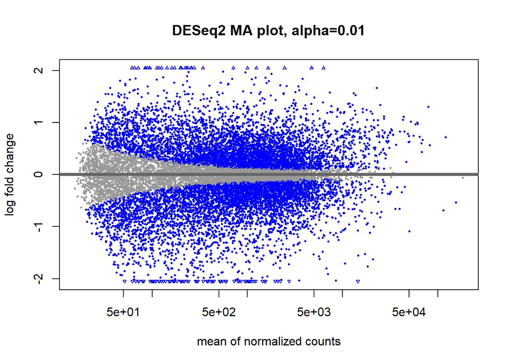

### 3.2.2 Vulcano-plot

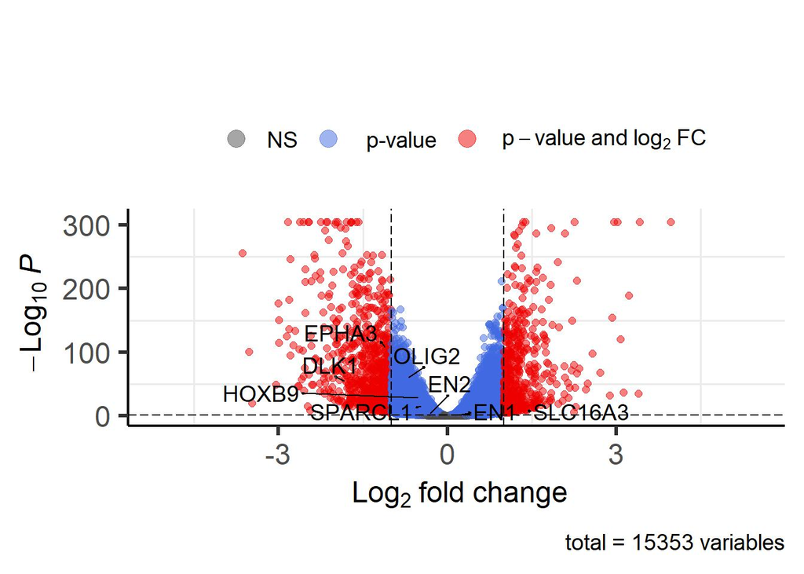

### 3.2.3 Heatmap

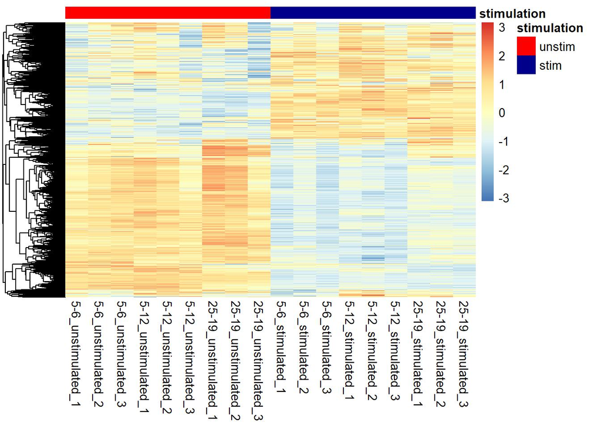